# Neurodevelopmental gene expression signatures

Urwah Nawaz

15 January 2020

# Paper summary

The study by Velmeshev et al (2019) analysed transcriptomic changes in the brains of individuals with autism to gain insight into the molecular pathology of ASD in a cell-type specifc manner.

The study used single-nucleus RNA-sequencing strategy on postmortem tissue samples including the prefrontal cortex and anerior cingulator cortex from 15 ASD patients and 16 controls. None of the ASD patients were diagnosed with ID. Additionally, patients that only had sporadic epilespy were also included in this analysis along with 7 age matched controls.

## Characteristics of the data

- Generated 104,559 single-nuclei gene expression profiles
- 52,556 from control subjects
- 52,003 from ASD patients
- Detected a median of 1391 genes and 2213 transcripts per nucleus
- Identified 17 cell types by using expression of known cell markers
- Neurons expressed more genes and transcripts than glia
- highlight key results from this study
  - what is single nucleus data
  - why is it better to study instead of snRNA-seq for some scenarios

## Differential expression results

The study aimed to identify differentially expressed genes in cell-type specific manner by comparing nuclear profiles from ASD and controls using a linear mixed model.

- Detected 692 differential expression events (q value < 0.05; expression level change > 10%) in 513 unique DEGs
- 76% of these were differentisally expressed in a single cell type
- Top differentially expressed genes in non-neuronal cell types were up-regulated in protoplasmic astrocytes and microglia
- 75 DEGs were found in the SFARI database
- SFARI genes were most overrepresented in L2/3 and L4 excitatory neurons, followed by VIP and somatostatin expression interneurons

Gene expression was also investigated in neuronal and glial subtypes. Over all this analysis revealed dysregulated development and synaptic signaling in components of upper-layer cortical circuitry as well as changes in the cellular state of microglia and protoplasmic astrocytes

# Aim of analysis

To use a single-nucleus data from ASD cases and controls and calculate a “neurodevelopmental gene dysregulation score” for each ASD case and each control.

Each of the genes may only show a minor change and different genes may be changed in different patients, however when we look at them as a group, we might see a cumulative effect.

# Method Aims

- Download data from Vekmeshev et al and create a expression matrix
- Make a list of neurodevelopmental disease genes with subcategories
- Load data into R and perform an exploratory analysis
- For each NDD gene
  - Calculate the z-score of its expression in a given individual and cell type relative to all cells from controls in the same cell-type
  - Box-plot these z-scores
  - Calculate a wilcoxon test comparing NDD genes and non-NDD genes for each individual

# Analysis

## Gene lists

For this analysis, we want to investigate the expression of NDD genes in ASD individuals compared to controls.

Neurodevelopmental disorder gene lists:

```r
suppressPackageStartupMessages({
  library(pander)
  library(kableExtra)
  library(tibble)
  library(magrittr)
  library(dplyr)
  library(rmarkdown)
  library(gdata)
  library(biomaRt)
  library(EnsDb.Hsapiens.v79)
})
```

- **ASD related genes**

List of genes was downloaded from SFARI database and includes 913 genes in total

```r
ASD_genes <- read.csv("~/Documents/Lists/SFARI-Gene_genes_01-03-2020release_02-06-2020export.csv")


ASD_genes %>%
  dplyr::select("gene.symbol", "gene.name", "ensembl.id",
                "chromosome", "gene.score", "number.of.reports") %>%
  kable(escape = F, align = "c") %>%
  kable_styling(c("striped", "condensed"), full_width = F) %>%
  kable_styling(bootstrap_options = "striped", full_width = F) %>%
  scroll_box(width = "1000px", height = "200px")
```

| gene.symbol | gene.name | ensembl.id | chromosome | gene.score | number.of.reports |
| --- | --- | --- | --- | --- | --- |
| ABAT | 4-aminobutyrate aminotransferase | ENSG00000183044 | 16 | 3 | 5 |
| ABCA10 | ATP-binding cassette, sub-family A (ABC1), member 10 | ENSG00000154263 | 17 | 3 | 1 |
| ABCA13 | ATP binding cassette subfamily A member 13 | ENSG00000179869 | 7 | 3 | 6 |
| ABCA7 | ATP-binding cassette, sub-family A (ABC1), member 7 | ENSG00000064687 | 19 | 3 | 4 |
| ACE | angiotensin I converting enzyme | ENSG00000159640 | 17 | 3 | 3 |
| ACHE | Acetylcholinesterase (Yt blood group) | ENSG00000087085 | 7 | 2 | 4 |
| ACTB | actin beta | ENSG00000075624 | 7 | 1 | 3 |
| ACTL6B | actin like 6B | ENSG00000077080 | 7 | NA | 8 |
| ACTN4 | actinin alpha 4 | ENSG00000130402 | 19 | 3 | 4 |
| ACY1 | aminoacylase 1 | ENSG00000243989 | 3 | NA | 9 |
| ADA | adenosine deaminase | ENSG00000196839 | 20 | 2 | 7 |
| ADCY3 | adenylate cyclase 3 | ENSG00000138031 | 2 | 2 | 2 |
| ADCY5 | Adenylate cyclase 5 | ENSG00000173175 | 3 | 3 | 6 |
| ADK | adenosine kinase | ENSG00000156110 | 10 | 3 | 2 |
| ADNP | Activity-dependent neuroprotector homeobox | ENSG00000101126 | 20 | 1 | 39 |
| ADORA3 | Adenosine A3 receptor | ENSG00000282608 | 1 | 3 | 2 |
| ADSL | adenylosuccinate lyase | ENSG00000239900 | 22 | 1 | 6 |
| AFF2 | AF4/FMR2 family, member 2 | ENSG00000155966 | X | 1 | 15 |
| AGAP1 | ArfGAP with GTPase domain, ankyrin repeat and PH domain 1 | ENSG00000157985 | 2 | 3 | 8 |
| AGAP2 | ArfGAP with GTPase domain, ankyrin repeat and PH domain 2 | ENSG00000135439 | 12 | 2 | 4 |
| AGBL4 | ATP/GTP binding protein-like 4 | ENSG00000186094 | 1 | 3 | 3 |
| AGMO | alkylglycerol monooxygenase | ENSG00000187546 | 7 | 3 | 6 |
| AGO1 | argonaute 1, RISC catalytic component | ENSG00000092847 | 1 | 2 | 7 |
| AGO3 | argonaute RISC catalytic component 3 | ENSG00000126070 | 1 | 3 | 4 |
| AGO4 | argonaute RISC catalytic component 4 | ENSG00000134698 | 1 | 2 | 3 |
| AGTR2 | angiotensin II receptor, type 2 | ENSG00000180772 | X | 3 | 3 |
| AHDC1 | AT-hook DNA binding motif containing 1 | ENSG00000126705 | 1 | 1 | 11 |
| AHI1 | Abelson helper integration site 1 | ENSG00000135541 | 6 | NA | 19 |
| AKAP9 | A kinase (PRKA) anchor protein 9 | ENSG00000127914 | 7 | 2 | 5 |
| ALDH1A3 | aldehyde dehydrogenase 1 family member A3 | ENSG00000184254 | 15 | NA | 5 |

[output cut: 883 more lines]

The ASD risk genes from SFARI are scored from 1 to 3, where 1 is high confidence genes and 3 means that there is suggestive evidence for ASD risk.

- **Intellectual disability genes**

```r
ID_genes <- read.xls("~/Documents/Lists/ID_Speech_delay_genes.xls") %>%
  as.data.frame() %>%
  column_to_rownames("Gene")
geneSymbols <- as.character(rownames(ID_genes))
geneIDs <- ensembldb::select(EnsDb.Hsapiens.v79, keys= geneSymbols, keytype = "SYMBOL", columns = c("SYMBOL","GENEID"))
ID_genes_complete <- merge(as.data.frame(ID_genes),
                           as.data.frame(geneIDs), by.x = "row.names",
                           by.y = "SYMBOL", sort=FALSE)

ID_genes_complete %>%
  dplyr::select("Gene" = "Row.names", "GENEID","Phenotype") %>%
  kable(escape = F, align = "c") %>%
  kable_styling(c("striped", "condensed"), full_width = F) %>%
  kable_styling(bootstrap_options = "striped", full_width = F) %>%
  scroll_box(width = "1000px", height = "200px")
```

Gene

GENEID

Phenotype

AIMP1

ENSG00000164022

Leukodystrophy, hypomyelinating, 3, early infantile onset of global dev delay, lack of development, lack of speech acquisition, & peripheral spasticity, incl seizures

ALX3

ENSG00000156150

Frontonasal dysplasia 1, associated features MR & lack of language acquisition.

AP3B2

ENSG00000103723

Epileptic encephalopathy, early infantile, 48. severe to profound global developmental delay with intellectual disability & absent speech. Assoum et al. (2016)

APOPT1

ENSG00000256053

Mitochondrial Complex IV Deficiency, decreased cognition & speech impairment. spastic tetraparesis & seizures.

ERC1

ENSG00000082805

Can incl ID. 12P13.33 subtelomeric microdeletion is a rare genetic rearrangement ERC1/ELKS gene found in the smallest region of overlap could be a good candidate gene for CAS(childhood apraxia of speech)/DVD(developmental verbal dyspraxia)

ISCA2

ENSG00000165898

Multiple mitochondrial dysfunctions syndrome 4. neurodegenerative disorder patients show progressive loss of motor & social skills with hypotonia, spasticity, & nystagmus. Patients regress to a vegetative state with lack of eye contact & speech

LHX3

ENSG00000107187

Confirmed DD Gene. pituitary hormone deficiency combined type 3. incl MR with severe speech delay

PTRH2

ENSG00000141378

Infantile-onset multisystem neurologic, endocrine, & pancreatic disease incl mod ID with severe expressive speech delay

QRICH1

ENSG00000198218

Ververi-Brady syndrome incl dev delay, ASD, mild ID & speech delay Ververi et al. (2018)

TBC1D23

ENSG00000036054

Pontocerebellar hypoplasia, type 11 incl severely delayed psychomotor dev with ID & poor speech. Ivanova et al. (2017)

TMTC3

ENSG00000139324

Lissencephaly 8 incl ID with poor or absent speech, early-onset refractory seizures. Jerber et al. (2016)

TSEN15

ENSG00000198860

Pontocerebellar hypoplasia, type 2F. cognitive & motor delay, poor or absent speech, seizures, & spasticity

UQCC2

ENSG00000137288

Mitochondrial complex III deficiency, nuclear type 7. child showed delayed psychomotor development with lack of meaningful speech, & later developed autistic features & aggressive behavior.

DDOST

ENSG00000244038

Congenital disorder of glycosylation, type Ir. delayed psychomotor development with walking acquired at age 3 years, and never developed speech

ARID1A

ENSG00000117713

Coffin-Siris syndrome 2. Clinical features included hypotonia, feeding problems, vision problems, delayed psychomotor development with poor speech, & dysmorphic facial features

PIGV

ENSG00000060642

Hyperphosphatasia with mental retardation syndrome 1 . lack of speech & incl seizures

AHDC1

ENSG00000126705

Xia-Gibbs syndrome. failure to thrive, hypotonia, & delayed psychomotor dev with absent or poor expressive language

PPT1

ENSG00000131238

Ceroid lipofuscinosis, neuronal, 1. Can incl severe speech impairment, visual loss, and myoclonic seizures.

PPT1

LRG_690

Ceroid lipofuscinosis, neuronal, 1. Can incl severe speech impairment, visual loss, and myoclonic seizures.

SLC2A1

ENSG00000117394

Glut1 Deficiency Syndrome 2. onset of episodic ataxia & slurred speech associated with unilateral muscle weakness. gradual cognitive decline, progressive microcephaly, & ataxia during childhood.

ZEB2

ENSG00000169554

Mowat-Wilson syndrome . mental retardation, delayed motor development, epilepsy. Can incl severely impaired or absent speech

SCN2A

ENSG00000136531

Epileptic encephalopathy, early infantile, 11 . global motor, intellectual, & language impairment with no speech or purposeful movements.

TMEM237

ENSG00000155755

Joubert syndrome 14. severe mental retardation, lack of speech

GMPPA

ENSG00000144591

Alacrima, achalasia, and mental retardation syndrome. alacrima, feeding difficulties due to achalasia, and delayed psychomotor development with speech delay.

KIF1A

ENSG00000130294

Mental retardation, autosomal dominant 9. mild to severe global developmental delay and intellectual disability. Additional variable features included delayed language. Some had mild speech delay in the teenage years.

CTNNB1

ENSG00000168036

Mental retardation, autosomal dominant 19. severe intellectual disability with absent or very limited speech, microcephaly, and spasticity which severely impaired the ability to walk.

SETD2

ENSG00000181555

Luscan-Lumish syndrome. characterized by macrocephaly, ID, speech delay, low sociability, & behavioral problems. Can incl seizures

GLYCTK

ENSG00000168237

D-glyceric aciduria. Some patients have encephalopathic presentation, with severe MR, seizures, microcephaly, & sometimes early death, whereas others have a mild phenotype with only mild speech delay or even normal development

FOXP1

ENSG00000114861

Mental retardation with language impairment and with or without autistic features. moderate to severe speech delay that particularly affects expressive speech

ARL13B

ENSG00000169379

Joubert syndrome 8. incl delayed psychomotor development with absent speech

MANBA

ENSG00000109323

Mannosidosis, beta. developmental delay and mental retardation. delayed speech development

FAT4

ENSG00000196159

Van Maldergem syndrome 2 . intellectual disability, typical craniofacial features, auditory malformations resulting in hearing loss, and skeletal and limb malformations. Can incl no speech development

MFSD8

ENSG00000164073

Ceroid lipofuscinosis, neuronal, 7. developmental regression, seizures, mental and motor regression, speech impairments, ataxia, visual failure, and myoclonus.

KCTD7

ENSG00000243335

Epilepsy, progressive myoclonic 3, with or without intracellular inclusions. motor and speech regression

AUTS2

ENSG00000158321

Mental retardation, autosomal dominant 26. All patients had developmental delay and borderline to severe intellectual disability with poor speech

PEX1

ENSG00000127980

Peroxisome biogenesis disorder 1B (NALD/IRD). Many can communicate, although language is rare. Speech development ranged from nonverbal expression to grammatical speech and comprehensive reading.

AP4M1

ENSG00000221838

Spastic paraplegia 50, autosomal recessive. hypertonia & spasticity & severe MR with poor or absent speech dev

CNTNAP2

ENSG00000174469

Pitt-Hopkins like syndrome 1. delayed psychomotor development, ID, severe speech impairment or regression, & behavioral abnormalities. Most patients have onset of seizures within the first years of life.

TUSC3

ENSG00000104723

Mental retardation, autosomal recessive 7. patients had variable developmental delay with intellectual disability (IQ range, 40-50) and language delay

VPS37A

ENSG00000155975

Spastic paraplegia 53, autosomal recessive. All had mild to moderate cognitive & speech delay

TRAPPC9

ENSG00000167632

Mental retardation, autosomal recessive 13. significant speech delay

VLDLR

ENSG00000147852

Cerebellar hypoplasia and mental retardation with or without quadrupedal locomotion 1. lack of speech development

FRRS1L

ENSG00000260230

Epileptic encephalopathy, early infantile, 37. severely affected, with MR, absent speech, & impaired volitional movements

KCNT1

ENSG00000107147

Epileptic encephalopathy, early infantile, 14 . Other features included poor or no eye contact, lack of speech and walking, and microcephaly.

ATM

ENSG00000149311

boy with slurred speech, mild motor delays & learning disability diagnosed with atypical Ataxia-telangiectasia novel homozygous missense variant in ATM (c.5585T>A; p.Leu1862His) that resulted in protein instability J Hum Genet. 2017 Apr Roohi

ATM

LRG_135

boy with slurred speech, mild motor delays & learning disability diagnosed with atypical Ataxia-telangiectasia novel homozygous missense variant in ATM (c.5585T>A; p.Leu1862His) that resulted in protein instability J Hum Genet. 2017 Apr Roohi

DCPS

ENSG00000110063

Al-Raqad syndrome. moderate to severe ID with poor or absent speech

MGP

ENSG00000111341

Keutel syndrome. Other associated features may include hearing loss, recurrent otitis &/or sinusitis, mild ID, frequent respiratory infections, nasal speech & rarely, seizures, & short stature.

SOX5

ENSG00000134532

Lamb-Shaffer syndrome. global dev delay, ID, poor expressive speech, & mild dysmorphic facial features

TUBA1A

ENSG00000167552

Lissencephaly 3 severe MR & seizures. lack of language dev or poor language. microcephaly, hypotonia, refractory occipital seizures, left hemiparesis, lack of speech, and cortical blindness.

SCN8A

ENSG00000196876

Cognitive impairment with or without cerebellar ataxia. Epileptic encephalopathy, early infantile, 13 No speech or regression of speech

SLC25A15

ENSG00000102743

Hyperornithinemia-hyperammonemia-homocitrullinemia syndrome . mental retardation and myoclonic seizures. scanning speech

FOXG1

ENSG00000176165

Rett syndrome, congenital variant .severe MR absence of speech

AP4S1

ENSG00000100478

Spastic paraplegia 52, autosomal recessive. Incl severe MR with poor or absent speech development

TTC8

ENSG00000165533

Bardet-Biedl syndrome 8. retinitis pigmentosa, obesity, postaxial polydactyly, hypogonadism, and developmental delay . speech impediment

BRF1

ENSG00000185024

Cerebellofaciodental syndrome. delayed development, & variable ID with poor speech

MAGEL2

ENSG00000254585

Schaaf-Yang syndrome incl ID & seizures . lack of speech acquisition or speech defects

GATM

ENSG00000171766

MR, severe disturbance of expressive and cognitive speech

AP4E1

ENSG00000081014

Spastic paraplegia 51, autosomal recessive. hypertonia & spasticity & severe MR with poor or absent speech development

TELO2

ENSG00000100726

You-Hoover-Fong syndrome. Incl severely delayed global development, ID with absent speech, microcephaly

SLC13A5

ENSG00000141485

Epileptic encephalopathy, early infantile, 25. All patients had profound or severe delayed development with lack of speech

MECP2

ENSG00000169057

Xq28 duplication(MECP2). Delayed speech and language development;Intellectual disability;Muscular hypotonia;Recurrent infections;Seizures;Spasticity

CEP135

ENSG00000174799

Microcephaly 8, primary, autosomal recessive. severe cognitive deficits & unintelligible speech

GRM1

ENSG00000152822

Spinocerebellar ataxia, autosomal recessive 13. mild to profound MR with poor or absent speech as well as gait & stance ataxia & hyperreflexia.

COG5

ENSG00000164597

Congenital disorder of glycosylation, type Iii, incl mod MR with slow and inarticulate speech, truncal ataxia, and mild hypotonia

FOXP2

ENSG00000128573

Speech-language disorder-1, can incl mild MR & mild dev delay

PHF21A

ENSG00000135365

Kim 2012 identified 3 patients with balanced translocations disrupting the PHF21A gene. All 3 patients had ID, and 1 had no speech.

SRPX2

ENSG00000102359

Rolandic epilepsy, mental retardation, and speech dyspraxia

SET

ENSG00000119335

2018. 5 unrelated children with delayed development & intellectual disability with language delay & speech impairment. 1 patient had 2 seizures. Stevens et al. (2018)

VARS

ENSG00000096171

2018. Neurodevelopmental disorder with microcephaly, seizures, & cortical atrophy. severe dev delay, ID, severe microcephaly, & cortical atrophy. Karaca et al. (2015). incl seizures & no speech Stephen et al. (2018)

VARS

ENSG00000204394

2018. Neurodevelopmental disorder with microcephaly, seizures, & cortical atrophy. severe dev delay, ID, severe microcephaly, & cortical atrophy. Karaca et al. (2015). incl seizures & no speech Stephen et al. (2018)

VARS

ENSG00000224264

2018. Neurodevelopmental disorder with microcephaly, seizures, & cortical atrophy. severe dev delay, ID, severe microcephaly, & cortical atrophy. Karaca et al. (2015). incl seizures & no speech Stephen et al. (2018)

VARS

ENSG00000226589

2018. Neurodevelopmental disorder with microcephaly, seizures, & cortical atrophy. severe dev delay, ID, severe microcephaly, & cortical atrophy. Karaca et al. (2015). incl seizures & no speech Stephen et al. (2018)

VARS

ENSG00000227686

2018. Neurodevelopmental disorder with microcephaly, seizures, & cortical atrophy. severe dev delay, ID, severe microcephaly, & cortical atrophy. Karaca et al. (2015). incl seizures & no speech Stephen et al. (2018)

VARS

ENSG00000231116

2018. Neurodevelopmental disorder with microcephaly, seizures, & cortical atrophy. severe dev delay, ID, severe microcephaly, & cortical atrophy. Karaca et al. (2015). incl seizures & no speech Stephen et al. (2018)

VARS

ENSG00000231945

2018. Neurodevelopmental disorder with microcephaly, seizures, & cortical atrophy. severe dev delay, ID, severe microcephaly, & cortical atrophy. Karaca et al. (2015). incl seizures & no speech Stephen et al. (2018)

MED13

ENSG00000108510

2018. De novo mutations in MED13, a component of the Mediator complex, are associated with a novel neurodevelopmental disorder. 11 de novo muts in MED13 All patients had ID &/or dev delays, including speech delays or disorders. Biok 2018

TRAF7

ENSG00000131653

2018. Cardiac, facial, & digital anomalies with developmental delay. delayed motor & speech development, including 1 patient who showed developmental regression in early childhood. 2 patients had seizures Tokita 2018

WDR4

ENSG00000160193

2018. Speech & language delay & ID in a patient with WDR4 mutations. Chen X 2018. Mutation in WDR4 impairs tRNA m(7)G46 methylation & causes a distinct form of microcephalic primordial dwarfism. severe encephalopathy with seizures Shaheen 2015

CHD1

ENSG00000153922

2017. 5 unrelated girls with PILBOS, Pilarowski-Bjornsson syndrome. delayed dev, ID, often with autistic features, speech apraxia, & mild dysmorphic features. Some patients may have seizures.

SASS6

ENSG00000156876

Microcephaly 14, primary, autosomal recessive. all had severe mental retardation, impaired speech, & aggressive behavior. The 2 adult patients had seizures. 5-generation consanguineous Pakistani family Khan 2014

MMACHC

ENSG00000132763

Methylmalonic aciduria and homocystinuria, cblC type. developmental delay, seizures. Can incl impaired speech

AGA

ENSG00000038002

Aspartylglucosaminuria. The most characteristic feature is progressive mental retardation. developmental milestones, particularly speech, were slow, and they acquired only a simple vocabulary.

GCDH

ENSG00000105607

Glutaricaciduria, type I. severe speech impairment, incl MR & movement disorder

SNRPN

ENSG00000128739

Prader-Willi syndrome. Incl MR & speech delay

RNF135

ENSG00000181481

Confirmed DD Gene. Macrocephaly, macrosomia, facial dysmorphism syndrome, & delayed speech

NDN

ENSG00000182636

Prader-Willi syndrome, incl MR & speech delay

IGF1R

ENSG00000140443

Insulin-like growth factor I, resistance to, incl dev delay & poor language development.

GBA

ENSG00000177628

Gaucher disease (GD) incl dev delay. {Lewy body dementia, susceptibility to} demonstrated progressive dementia with a progressive language disorder characterized by dysarthria, paraphasia, and difficulty in finding words.

GBA

ENSG00000262446

Gaucher disease (GD) incl dev delay. {Lewy body dementia, susceptibility to} demonstrated progressive dementia with a progressive language disorder characterized by dysarthria, paraphasia, and difficulty in finding words.

C12orf4

ENSG00000047621

Mental retardation, autosomal recessive 66. delayed speech development. Identification of C12orf4 as a gene for autosomal recessive intellectual disability. Philips Clin Genet 2017

GRIN2A

ENSG00000183454

Epilepsy, focal, with speech disorder and with or without mental retardation

ROGDI

ENSG00000067836

Kohlschutter-Tonz syndrome. severe global developmental delay, early-onset intractable seizures, spasticity. almost all had no speech development

ROGDI

LRG_455

Kohlschutter-Tonz syndrome. severe global developmental delay, early-onset intractable seizures, spasticity. almost all had no speech development

- **Epilpsy genes**

```r
Epi_genes <- read.xls("~/Documents/Lists/Final_Epil_list_annotated_Jan19.xls")  %>%
  as.data.frame()

geneSymbols <- as.character(Epi_genes$old.list)
geneIDs <- ensembldb::select(EnsDb.Hsapiens.v79, keys= geneSymbols, keytype = "SYMBOL", columns = c("SYMBOL","GENEID"))

Epi_genes_complete <- merge(as.data.frame(Epi_genes),
                           as.data.frame(geneIDs), by.x = "old.list",
                           by.y = "SYMBOL", sort=FALSE)


Epi_genes_complete %>%
  as.data.frame() %>%
  dplyr::select("Gene" = "old.list", "GENEID", "Type") %>%
  kable(escape = F, align = "c") %>%
 kable_styling(c("striped", "condensed"), full_width = F) %>% kable_styling(bootstrap_options = "striped", full_width = F) %>%
  scroll_box(width = "1000px", height = "200px")
```

| Gene | GENEID | Type |
| --- | --- | --- |
| GABRD | ENSG00000187730 | Generalized epilepsy with febrile seizures plus (GEFS + ), Juvenile myoclonic epilepsy (JME), Idiopathic generalized epilepsy (IGE) |
| PEX10 | ENSG00000157911 |  |
| KCNAB2 | ENSG00000069424 | Potential_Epilepsy_genes |
| ACOT7 | ENSG00000097021 | Potential_Epilepsy_genes |
| CAMTA1 | ENSG00000171735 | Epilepsy_related_genes |
| PEX14 | ENSG00000142655 | Epilepsy_related_genes |
| MTOR | ENSG00000198793 | Epilepsy_related_genes |
| MTOR | LRG_734 | Epilepsy_related_genes |
| MTHFR | ENSG00000177000 | Epilepsy_related_genes |
| MTHFR | LRG_726 | Epilepsy_related_genes |
| ATP13A2 | ENSG00000159363 | Potential_Epilepsy_genes |
| ALDH4A1 | ENSG00000159423 | Epilepsy_related_genes |
| ALPL | ENSG00000162551 |  |
| ARID1A | ENSG00000117713 | Epilepsy_related_genes |
| PIGV | ENSG00000060642 | Epilepsy_related_genes |
| SLC9A1 | ENSG00000090020 | Epilepsy_related_genes |
| SNIP1 | ENSG00000163877 | Neuro_Associated_Epilepsy |
| PPT1 | ENSG00000131238 | Epilepsy_related_genes |
| PPT1 | LRG_690 | Epilepsy_related_genes |
| SLC2A1 | ENSG00000117394 | Idiopathic generalized epilepsy (IGE) |
| SZT2 | ENSG00000198198 | Early infantile epileptic encephalopathy (EIEE) |
| ST3GAL3 | ENSG00000126091 | Early infantile epileptic encephalopathy (EIEE) |
| POMGNT1 | ENSG00000085998 | Epilepsy_related_genes |
| STIL | ENSG00000123473 |  |
| CPT2 | ENSG00000157184 | Epilepsy_related_genes |
| DHCR24 | ENSG00000116133 | Epilepsy_related_genes |
| DOCK7 | ENSG00000116641 | Early infantile epileptic encephalopathy (EIEE) |
| DNAJC6 | ENSG00000116675 | Epilepsy_related_genes |
| CTH | ENSG00000116761 | Epilepsy_related_genes |
| DPYD | ENSG00000188641 | Epilepsy_related_genes |

[output cut: 1426 more lines]

The ID and Epilpsy genes have been curated in-house after an in-depth literature analysis.

There are overlapping genes for each category, however for the purpose of this analysis, we will keep the groups as they are.

## Exploratory analysis

```r
suppressPackageStartupMessages({
  library(stringr)
  library(Biobase)
  library(SingleCellExperiment)
  library(scater)
  library(readr)
  library(ggplot2)
  library(ggpubr)
})
```

```r
meta <- read.table("~/Documents/Data/Autism/meta.tsv", header=TRUE, sep = "\t", as.is = TRUE, row.names = 1)
rownames(meta) <- str_replace(rownames(meta), "-", ".")
```

Number of cells belonging to each cluster:

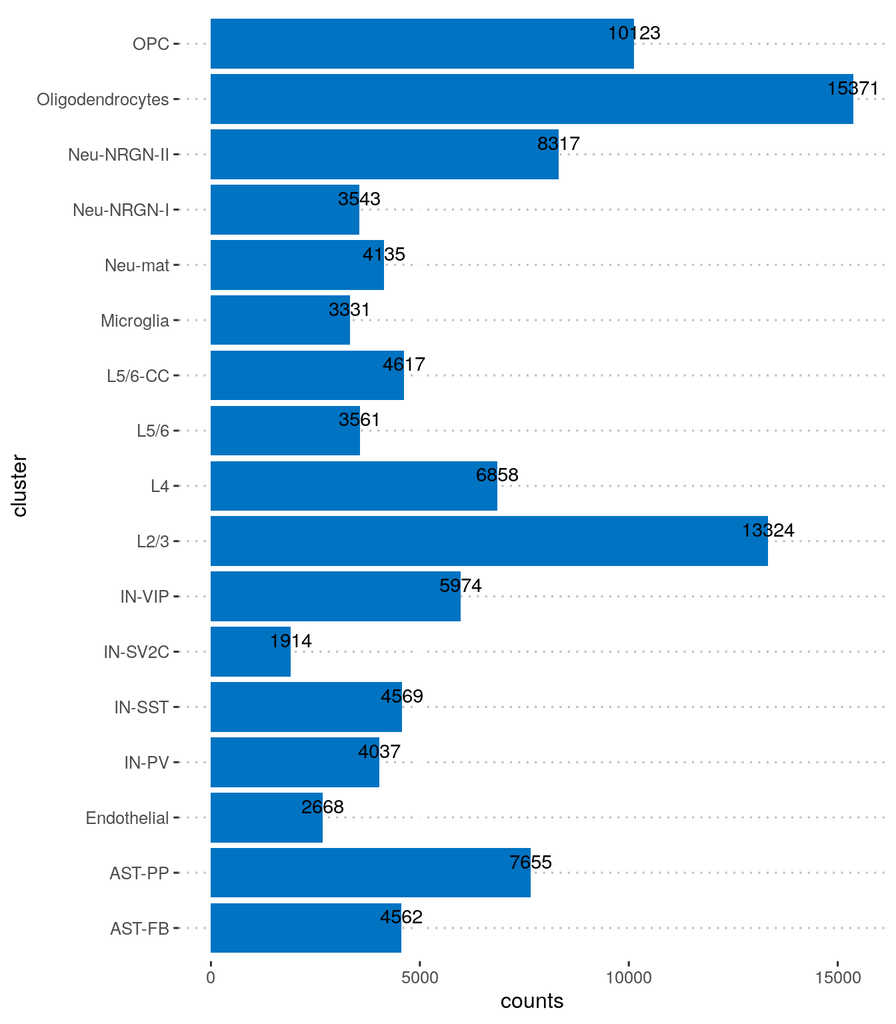

```r
meta %>%
  group_by(cluster) %>%
  summarise(counts = n()) %>%
  ggplot(aes(x = cluster, y = counts)) +
  geom_bar(fill = "#0073C2FF", stat = "identity") +
  geom_text(aes(label = counts), vjust = -0.3) + coord_flip() +
  theme_pubclean()
```

Number of cells belonging to each diagnosis (ASD or Control):

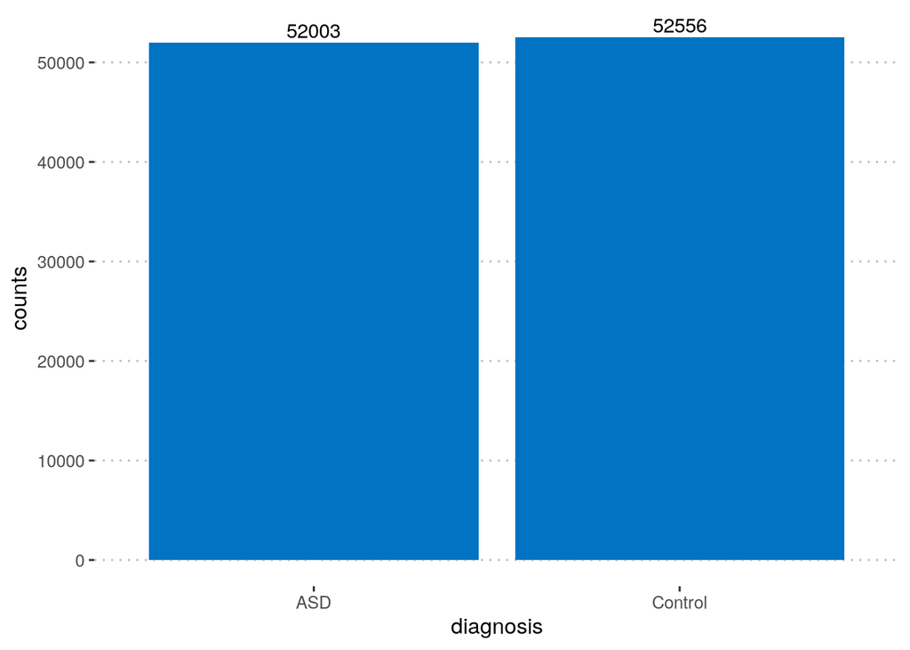

```r
meta %>%
  group_by(diagnosis) %>%
  summarise(counts = n()) %>%
  ggplot(aes(x = diagnosis, y = counts)) +
  geom_bar(fill = "#0073C2FF", stat = "identity") +
  geom_text(aes(label = counts), vjust = -0.3) +
  theme_pubclean()
```

### Detection of gene expression

```r
suppressPackageStartupMessages({
  library(scater)
  library(Matrix)
  library(SingleCellExperiment)
  library(DropletUtils)
  library(tidyverse)
})
```

```r
sn_counts <- readMM("~/Documents/Data/Autism/matrix.mtx")
genes <- read_tsv("~/Documents/Data/Autism/genes.tsv", col_names = FALSE)
barcodes <- read_tsv("~/Documents/Data/Autism/barcodes.tsv", col_names=FALSE)
sce <- SingleCellExperiment(
  assays=list(counts = sn_counts),
  rowData = genes$X1 ,
  colData = barcodes,
  metadata = meta
)

rownames(sce) <- genes$X1
```

```r
per.cell <- perCellQCMetrics(sce)
colData(sce) <- cbind(colData(sce), per.cell)
```

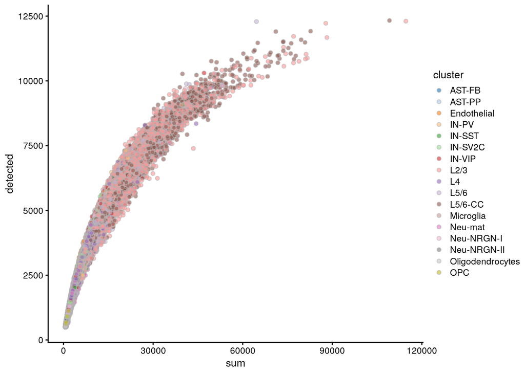

```r
sce$cluster <- meta$cluster
plotColData(sce, x="sum", y="detected", colour_by = "cluster")
```

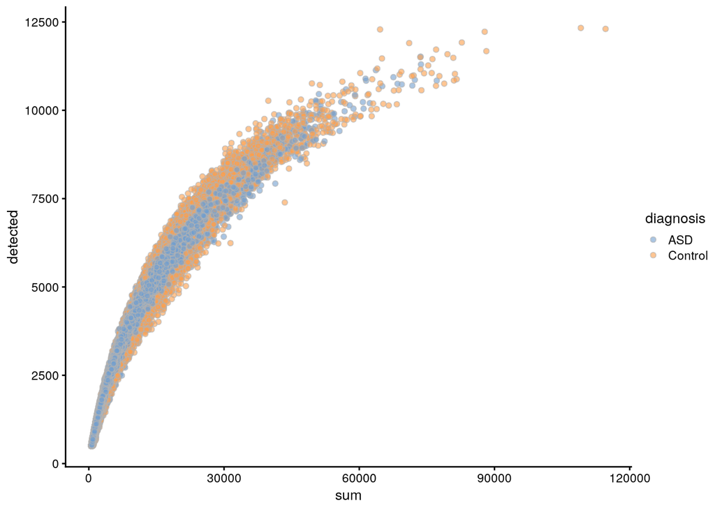

```r
sce$diagnosis <- meta$diagnosis
plotColData(sce, x="sum", y="detected", colour_by = "diagnosis")
```

```r
#per.feat <- perFeatureQCMetrics(sce)
```

```r
ave <- calculateAverage(sce)
```

```r
sce <- logNormCounts(sce)
```

```r
assays(sce)
```

```
## List of length 2
## names(2): counts logcounts
```

```r
#plotRowData(sce, aes(x = , y = n_cells_counts,
 #                                 colour = log10_mean_counts))
```

### Visualizing expression values

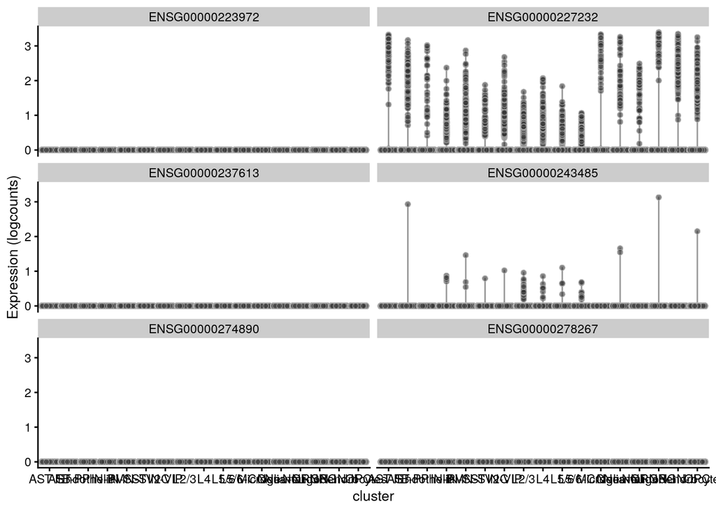

```r
## top 6 genes

plotExpression(sce, rownames(sce)[1:6], x = "cluster")
```

checklist

- Genes detected
- mean expression of genes
- expression of NDD vs non-NDD genes in clusters
- which cluster expresses the most amount of NDD genes
- variance of expression

## Gene expression signature analysis

Checklist

- write function for z-score calculation
- Must subset 1 ASD individual, all controls in 1 cell type per gene
- must group (average) expression of cells per individual
- transpose and calculate z-score
- End must be matrix with z-score for each cluster for each gene
- Plot boxplot for top 10 interesting genes (per gene list)?

# Notes

## Single-nucleus RNA-seq

Single-nucleus RNA-seq strategies involve analyzing the nuclei instead of cells. This method is advantegeous when attempting to profile expression in cells that are difficult to isolate such as frozen tissue samples.

More reading here:

https://www.biocompare.com/Editorial-Articles/557506-Advantages-of-Single-Nucleus-RNA-Sequencing/

https://jasn.asnjournals.org/content/30/1/23

## Normalization in sc-RNAseq

Various normalization methods exist for bulk RNA-seq which can be applied to sc-RNAseq, however sources of variation specific to sc-RNAseq such as technical dropouts make it necessary to have normalization methods specific to sc-RNAseq

- Most commonly used normalization method includes CPM normalization
- CPM normalization assumes that all cells in the dataset initially contain an equal number of mRNA molecules and count depth differences arise only due to sampling.
- After normalization, data matrices are typically log(x+1) transformation. This transformation has three main effects:
- Distances between log-transformed expression values represent log fold changes
- Log transformations mitigates mean variance relationship in sc data
- Log transformation reduces the skewness of the data to approximate the assumption of a data that is normally distributed